# Diversidad y estructura genética de *Pocillopora* spp en Bahía Culebra

Load libraries

```r
library(tidyverse)      # v2.0.0
library(pegas)          # v1.3
library(poppr)          # v2.9.5
library(adegenet)       # V2.1.10
library(PopGenUtils)    # v.0.1.8
library(hierfstat)      # v0.5-11
library(RClone)         # v1.0.3
library(gt)             # v.0.11.0
library(RColorBrewer)   # v1.1-3
```

Load genind data

```r
load(file = "genind_pocillopora.RData")
```

## Hardy-Weinberg Equilibrum

```r
hw.test(genind_pocillopora)
```

```
##              chi^2 df  Pr(chi^2 >) Pr.exact
## Pd2_001 222.817382  6 0.000000e+00    0.000
## Pd2_006  30.315439 10 7.605426e-04    0.043
## Pd2_007 246.785529 55 0.000000e+00    0.000
## Pd3_009 198.663114 21 0.000000e+00    0.000
## Pd3_008   9.235243  6 1.607740e-01    0.070
## Pd3_002  84.043338  6 5.551115e-16    0.000
## Pd3_010  53.109504  3 1.737410e-11    0.000
## Pd3_004  87.051772  6 1.110223e-16    0.000
## Pd4      90.000000  1 0.000000e+00    0.000
## Pd11    300.880223 45 0.000000e+00    0.000
## PV5     350.873475 45 0.000000e+00    0.000
```

# Clonal Structure

## Accumulation Curve

This plot shows if the data is enough to distinguish clones among samples. A plateau should be reached.

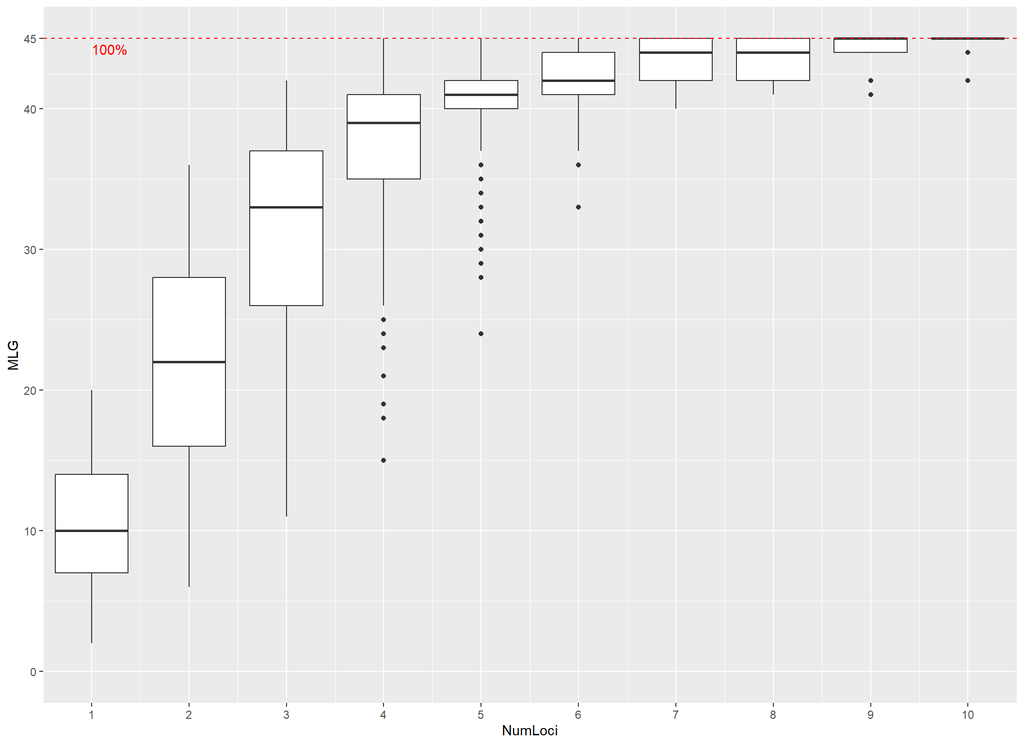

```r
genotype_curve(genind_pocillopora,
               sample = 1000,
               dropna = T)
```

Based on the plot, 7 loci are enough.

## Probability of Identity

```r
pid<-pid_calc(genind_pocillopora)
pid
```

```
## $pid_by_loc
##    Pd2_001    Pd2_006    Pd2_007    Pd3_009    Pd3_008    Pd3_002    Pd3_010
## 0.15683874 0.25660715 0.15572045 0.16242888 0.26129452 0.18705512 0.35386854
##    Pd3_004        Pd4       Pd11        PV5
## 0.17774686 0.38327581 0.04822846 0.11609686
##
## $pid_comb
## [1] 6.715991e-09
##
## $pidsibs_by_loc
##   Pd2_001   Pd2_006   Pd2_007   Pd3_009   Pd3_008   Pd3_002   Pd3_010   Pd3_004
## 0.4517405 0.5226394 0.4691153 0.4515705 0.5516508 0.4855932 0.5849961 0.4609794
##       Pd4      Pd11       PV5
## 0.6037202 0.3455448 0.4300016
##
## $pidsibs_comb
## [1] 0.0003240992
```

## Multilocus Genotypes

When different samples posses the same genotype for every locus they are treated as the same individual.

```r
poppr(genind_pocillopora)
```

```
##          Pop  N MLG eMLG   SE    H     G lambda   E.5  Hexp   Ia rbarD
## 1     Jicaro 30   3  3.0 0.00 0.77  1.82  0.451 0.709 0.217 3.27 0.614
## 2   Matapalo 30  12 12.0 0.00 2.03  5.42  0.816 0.667 0.557 5.42 0.611
## 3 Zapotillal 30  30 30.0 0.00 3.40 30.00  0.967 1.000 0.595 1.29 0.144
## 4      Total 90  45 18.4 2.16 3.17 11.74  0.915 0.473 0.632 3.64 0.371
##                 File
## 1 genind_pocillopora
## 2 genind_pocillopora
## 3 genind_pocillopora
## 4 genind_pocillopora
```

All three populations have 30 samples but only Zapotillal has 30 MLGs. On the contrary, Jícaro has only 3 MLGs.

To see the distribution of these MLGs they can be plotted.

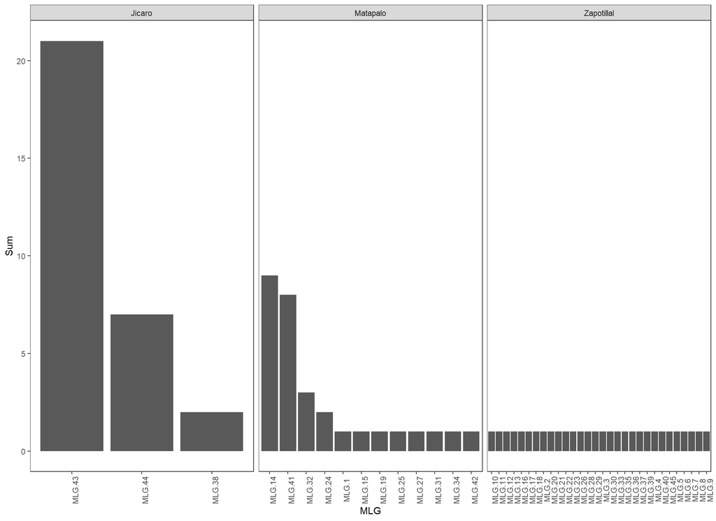

```r
# plot
graf<-as.data.frame(mlg.table(genind_pocillopora,
                              background = T, plot = F))

graf$pops<-rownames(graf)
graf2<-pivot_longer(graf, cols = contains("MLG"),
                    names_to = "MLG", values_to = "Sum_MLG")

graf2<-aggregate(Sum_MLG~MLG+pops, graf2, sum)

graf2 %>%
  mutate(MLG=as.factor(MLG)) %>%
  filter(Sum_MLG>0)  %>%
  ggplot(aes(reorder(MLG, desc(Sum_MLG)),  Sum_MLG))+
  geom_col(width = 0.9)+
  facet_grid(~pops, scales = "free_x")+
  theme_bw()+
  labs(x= "MLG", y="Sum")+
  theme(axis.text.x = element_text(angle = 90),
        panel.grid = element_blank(),)
```

## Mininum Spanning Network

Relationship among MLG can also be observed by using an haplotype network (minimum spanning networks).

**Note: the network looks awkward here, but it looks fine when saving it as tiff.

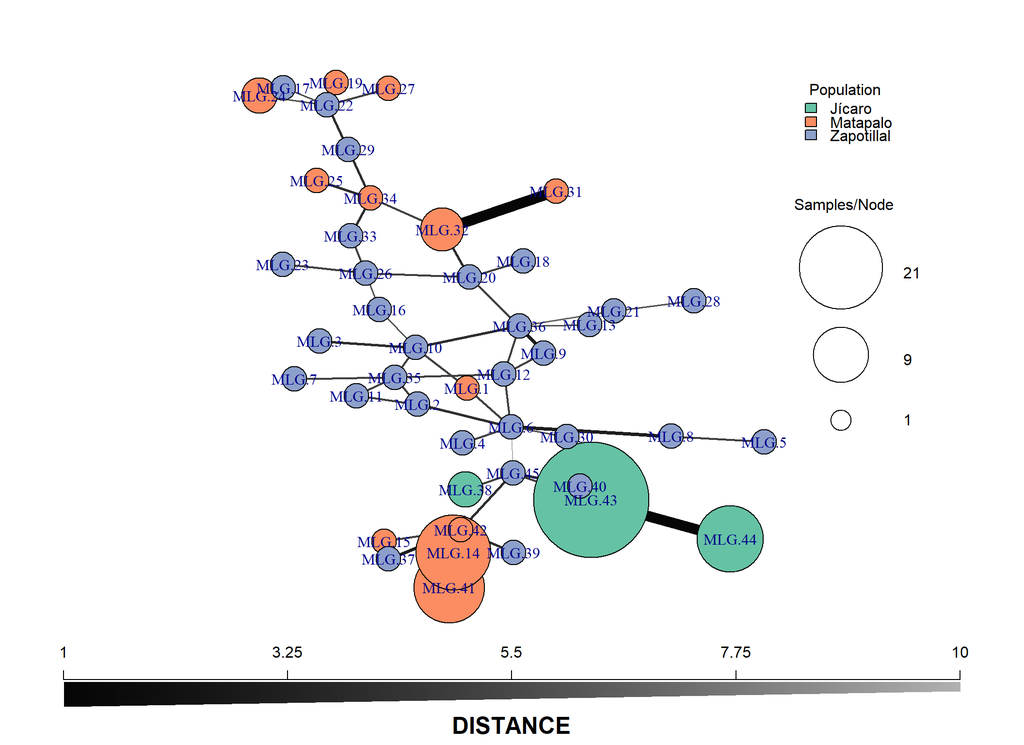

```r
# Calculate a distance matrix
dist<-diss.dist(genind_pocillopora, percent = F, mat = F)

# Create the minimum spanning network
network<-poppr.msn(genind_pocillopora, distmat = dist,
                   showplot = F, include.ties = T)


# Draw the plot
cols = c("#66C2A5", "#FC8D62", "#8DA0CB")

# haplotype network

set.seed(15) # every time the plot is run, a different plot will be shown
plot_poppr_msn(genind_pocillopora, network, inds = "ALL",
               mlg = T,
               gadj = 1.5, palette = cols, gweight = 2,
               cutoff = NULL, quantiles = FALSE,
               nodescale = 100, size.leg = F, pop.leg = F)

# Add legend
## Circles
legend(x= 0.787, y = 0.80, legend = c("", "", ""),
       pch = 1, pt.cex = c(12, 8, 3), bty = "n",
       y.intersp = c(2.4, 7, 0.00001),
       title = "Samples/Node")

## MLGs
text(x = rep(0.9, 3),
     y = c(0.656, 0.65 - 0.145, 0.65 - 0.250),
     labels = c("21", "9", "1"), pos = 4,
     cex = 1, col = "black")

## Population
legend(x = 0.787, y = 1.0, title = "Population",
       bty = "n", y.intersp = c(0.8, 0.7, 0.7, 0.7),
       legend = c("Jícaro", "Matapalo", "Zapotillal"),
       pch = NA, fill = cols)
```

The poppr function provides values for N (samples) and MLGs, so clonal richness can be calculated by using the formula R = (MLG-1) / (N-1). R can also be obtained with RClone

```r
# transform data to RClone format

df<-genind2df(genind_pocillopora) # from genind to dataframe
pobs<-df$pop                      # assign populations
datos<-df %>% select(-pop)        # remove populations from df

# RClone does not recognize NA values, so they will be input as 999

nulos<-which(is.na(datos))
matriz<-as.matrix(datos)
matriz[nulos]<-999
datos<-as.data.frame(matriz)

# Convert to RClone
clones<-convert_GC(datos, 3)

# Calculate Clonal Richness
riq_clon<-clonal_index(clones, vecpop = pobs)
riq_clon
```

```
##             N  G          R       H''        J'         D         V     Hill
## Jicaro     30  3 0.06896552 0.7697762 0.7006805 0.4666667 0.6008230 1.875000
## Matapalo   30 12 0.37931034 2.0314412 0.8175121 0.8436782 0.6936027 6.397059
## Zapotillal 30 30 1.00000000        NA        NA        NA        NA       NA
```

# Clone correction

Data should be corrected to avoid bias

```r
# Para tener datos con la correción por clones
pocillopora_cc<-clonecorrect(genind_pocillopora,
                             strata = ~Poblacion)
```

A little test to observe how HWE changed from whole data to clone corrected.

```r
hw.test(genind_pocillopora)
```

```
##              chi^2 df  Pr(chi^2 >) Pr.exact
## Pd2_001 222.817382  6 0.000000e+00    0.000
## Pd2_006  30.315439 10 7.605426e-04    0.045
## Pd2_007 246.785529 55 0.000000e+00    0.000
## Pd3_009 198.663114 21 0.000000e+00    0.000
## Pd3_008   9.235243  6 1.607740e-01    0.083
## Pd3_002  84.043338  6 5.551115e-16    0.000
## Pd3_010  53.109504  3 1.737410e-11    0.000
## Pd3_004  87.051772  6 1.110223e-16    0.000
## Pd4      90.000000  1 0.000000e+00    0.000
## Pd11    300.880223 45 0.000000e+00    0.000
## PV5     350.873475 45 0.000000e+00    0.000
```

```r
hw.test(pocillopora_cc)
```

```
##              chi^2 df  Pr(chi^2 >) Pr.exact
## Pd2_001  89.484162  6 0.000000e+00    0.000
## Pd2_006  20.518376 10 2.471387e-02    0.047
## Pd2_007 111.675895 55 9.815741e-06    0.000
## Pd3_009  88.497014 21 2.928185e-10    0.000
## Pd3_008   1.625675  6 9.507138e-01    0.960
## Pd3_002  37.677308  6 1.298892e-06    0.000
## Pd3_010  11.224490  3 1.057189e-02    0.004
## Pd3_004  56.872045  6 1.939194e-10    0.000
## Pd4      45.000000  1 1.970346e-11    0.000
## Pd11    139.379960 45 1.385247e-11    0.000
## PV5     159.052422 45 1.199041e-14    0.000
```

```r
# Pd2-006 is not treated as following HWE as p value varies near 0.05
# however, Pd3-008 always show a p value greater than 0.05
```

# Genetic diversity

## Diversity by locus

```r
locus_table(pocillopora_cc,index = "simpson",lev = "allele")
```

```
##          summary
## locus     allele   1-D  Hexp Evenness
##   Pd2_001   4.00  0.67  0.68     0.88
##   Pd2_006   5.00  0.65  0.66     0.79
##   Pd2_007  11.00  0.81  0.82     0.68
##   Pd3_009   7.00  0.57  0.58     0.58
##   Pd3_008   4.00  0.69  0.70     0.86
##   Pd3_002   4.00  0.70  0.71     0.93
##   Pd3_010   3.00  0.51  0.54     0.77
##   Pd3_004   4.00  0.41  0.41     0.57
##   Pd4       2.00  0.37  0.37     0.79
##   Pd11     10.00  0.79  0.80     0.73
##   PV5      10.00  0.84  0.85     0.85
##   mean      5.82  0.64  0.65     0.77
```

The amount of alleles ranges from 2 (Pd4) to 11 (Pd2-007). Other diversity indexes are shown in the table. Other stats are shown with the basic.stats function:

```r
# stats by locus
estadisticas<-basic.stats(pocillopora_cc, diploid = T, digits = 3)

# generate table
tabla<-rbind(estadisticas$perloc, estadisticas$overall)
rownames(tabla)[12]<-"mean"
tabla$Locus<-rownames(tabla)
tabla %>%
  select(Locus, everything()) %>%
  gt() %>%
  opt_stylize(style = 1)
```

| Locus | Ho | Hs | Ht | Dst | Htp | Dstp | Fst | Fstp | Fis | Dest |
| --- | --- | --- | --- | --- | --- | --- | --- | --- | --- | --- |
| Pd2_001 | 0.156 | 0.576 | 0.700 | 0.124 | 0.762 | 0.186 | 0.178 | 0.245 | 0.730 | 0.439 |
| Pd2_006 | 0.550 | 0.634 | 0.627 | -0.007 | 0.624 | -0.010 | -0.011 | -0.016 | 0.133 | -0.027 |
| Pd2_007 | 0.506 | 0.669 | 0.784 | 0.115 | 0.842 | 0.172 | 0.147 | 0.205 | 0.245 | 0.521 |
| Pd3_009 | 0.417 | 0.544 | 0.691 | 0.148 | 0.765 | 0.221 | 0.214 | 0.289 | 0.233 | 0.485 |
| Pd3_008 | 0.617 | 0.604 | 0.623 | 0.020 | 0.633 | 0.029 | 0.031 | 0.046 | -0.021 | 0.074 |
| Pd3_002 | 0.370 | 0.501 | 0.654 | 0.154 | 0.731 | 0.231 | 0.235 | 0.316 | 0.260 | 0.462 |
| Pd3_010 | 0.167 | 0.141 | 0.547 | 0.406 | 0.750 | 0.609 | 0.742 | 0.812 | -0.182 | 0.709 |
| Pd3_004 | 0.262 | 0.454 | 0.670 | 0.216 | 0.778 | 0.324 | 0.323 | 0.417 | 0.424 | 0.594 |
| Pd4 | 0.000 | 0.265 | 0.513 | 0.248 | 0.637 | 0.372 | 0.484 | 0.584 | 1.000 | 0.506 |
| Pd11 | 0.661 | 0.808 | 0.862 | 0.054 | 0.889 | 0.081 | 0.063 | 0.091 | 0.182 | 0.423 |
| PV5 | 0.161 | 0.806 | 0.835 | 0.029 | 0.850 | 0.044 | 0.035 | 0.051 | 0.801 | 0.225 |
| mean | 0.351 | 0.546 | 0.683 | 0.137 | 0.751 | 0.205 | 0.201 | 0.274 | 0.356 | 0.452 |

## Diversity per population

### Allelic Richness

```r
# Set analysis by population
setPop(pocillopora_cc)<-~Poblacion

# Calculate allelic richness
riqueza<-allelic.richness(pocillopora_cc, diploid = T)

# Mean
round(apply(riqueza$Ar, MARGIN = 2, FUN = mean), 3)
```

```
##     Jicaro   Matapalo Zapotillal
##      1.697      2.390      2.343
```

```r
# SD
round(apply(riqueza$Ar, MARGIN = 2, FUN = sd), 3)
```

```
##     Jicaro   Matapalo Zapotillal
##      0.545      0.671      0.562
```

### Observed Heterocygosity

```r
# basic.stats is used for H0, He and FIS
estadisticas<-basic.stats(pocillopora_cc, diploid = T, digits = 3)

round(apply(estadisticas$Ho, MARGIN = 2, FUN = mean), 3)
```

```
##     Jicaro   Matapalo Zapotillal
##      0.348      0.332      0.374
```

```r
round(apply(estadisticas$Ho, MARGIN = 2, FUN = sd), 3)
```

```
##     Jicaro   Matapalo Zapotillal
##      0.337      0.316      0.250
```

### Expected Heterocygosity

```r
estadisticas<-basic.stats(pocillopora_cc, diploid = T, digits = 3)

round(apply(estadisticas$Hs, MARGIN = 2, FUN = mean), 3)
```

```
##     Jicaro   Matapalo Zapotillal
##      0.364      0.624      0.598
```

```r
round(apply(estadisticas$Hs, MARGIN = 2, FUN = sd), 3)
```

```
##     Jicaro   Matapalo Zapotillal
##      0.277      0.248      0.205
```

### Inbreeding Coefficient (FIS)

```r
estadisticas<-basic.stats(pocillopora_cc, diploid = T, digits = 3)

round(colMeans(estadisticas$Fis, na.rm = T), 3)
```

```
##     Jicaro   Matapalo Zapotillal
##     -0.017      0.519      0.404
```

```r
# bootstrap
boot.ppfis(pocillopora_cc, nboot = 999)
```

```
## $call
## boot.ppfis(dat = pocillopora_cc, nboot = 999)
##
## $fis.ci
##        ll     hl
## 1 -0.3932 0.4500
## 2  0.2475 0.7117
## 3  0.1685 0.5904
```

### Private alleles

```r
alelosPrivados<-private_alleles(pocillopora_cc,
                                form = locus~.,
                                count.alleles = F,
                                report = "table")

apply(alelosPrivados, 1, sum)
```

```
##     Jicaro   Matapalo Zapotillal
##          3          3         13
```

```r
save(pocillopora_cc, file = "pocillopora_cc.RData")
```